# Examen Final - Métodos Empíricos en Macroeconomía Estructural (réplica en R)

Réplica de `Examen_Final.m` y contraste con `Examen Final (R).pdf` / `Examen_final.mat`

# Alcance y convenciones

Este documento replica **línea por línea** el código MATLAB `Examen_Final.m` (incluida `var_ls.m`), *sin corregirlo*: la idea es reproducir lo que hizo el script original y dejar constancia de dónde los resultados difieren de lo reportado en `Examen Final (R).pdf` y del archivo `Examen_final.mat` (que guarda los resultados que produjo MATLAB). Las diferencias se resumen en la sección final.

Convenciones del port:

- Las matrices se mantienen con la misma orientación que en MATLAB (variables en filas, tiempo en columnas).
- `prctile` de MATLAB equivale a `quantile(..., type = 5)` en R.
- La semilla (`12345`) se fija con `set.seed`, pero el generador de números aleatorios de R **no** es el de MATLAB; por eso las bandas de confianza (bootstrap) solo pueden coincidir de forma aproximada, nunca exacta.
- El signo de un autovector es arbitrario. Para la identificación del *news shock* se adopta la normalización “impacto positivo sobre *Hours*”, que es la que exhibe el `.mat`.

# Datos

```r
base <- read_excel("Base.xlsx", sheet = 2)          # base definitiva (260 obs.)
set.seed(12345)

var_tfp          <- base[[2]]
var_output       <- base[[3]]
var_consumption  <- base[[4]]
var_hours        <- base[[5]]
var_stock_prices <- base[[6]]
var_inflation    <- base[[7]]
var_confidence   <- base[[8]]

# Arrays con variables en filas y tiempo en columnas
Y4 <- t(cbind(var_tfp, var_consumption, var_output, var_hours))
Y7 <- t(cbind(var_tfp, var_consumption, var_output, var_hours,
              var_stock_prices, var_inflation, var_confidence))

cat("Observaciones:", ncol(Y4), " - Período:", base$date[1], "a", base$date[nrow(base)], "\n")
```

```
## Observaciones: 260  - Período: 1960:Q1 a 2024:Q4
```

# Funciones

## `var_ls` (estimación de un VAR(p) por MCO; Hevia)

```r
var_ls <- function(data, p, pmax = p) {
  if (p > pmax) stop("p debe ser <= pmax")
  if (nrow(data) > ncol(data)) data <- t(data)

  maxlag <- max(pmax, p)
  nobs   <- ncol(data) - maxlag
  k      <- nrow(data)

  Y <- data[, (maxlag + 1):ncol(data), drop = FALSE]
  Z <- matrix(0, k * p + 1, nobs)
  Z[1, ] <- 1
  for (i in 1:p) {
    Z[(2 + (i - 1) * k):(1 + i * k), ] <- data[, (maxlag + 1 - i):(maxlag + nobs - i)]
  }

  ZZi   <- solve(Z %*% t(Z))
  beta  <- Y %*% t(Z) %*% ZZi
  resid <- Y - beta %*% Z
  Omega <- resid %*% t(resid) / nobs

  # sderr = sqrt(diag(kron(inv(ZZ'), Omega))) ordenado como beta
  sderr_beta <- sqrt(outer(diag(Omega), diag(ZZi)))
  tval_beta  <- beta / sderr_beta

  nv      <- k * (k * p + 1)
  loglike <- -(nobs / 2) * (k * log(2 * pi) + k + log(det(Omega)))
  AIC     <- (-2 * loglike + 2 * nv) / nobs
  SIC     <- (-2 * loglike + nv * log(nobs)) / nobs
  HQC     <- (-2 * loglike + 2 * nv * log(log(nobs))) / nobs

  out <- list(lags = p, const = beta[, 1], resid = resid, Omega = Omega,
              loglike = loglike, AIC = AIC, SIC = SIC, HQC = HQC,
              nobs = nobs, npar = nv,
              coef  = lapply(1:p, function(i) beta[, (2 + (i - 1) * k):(1 + i * k), drop = FALSE]),
              sderr = list(const = sderr_beta[, 1],
                           coef = lapply(1:p, function(i) sderr_beta[, (2 + (i - 1) * k):(1 + i * k), drop = FALSE])),
              tval  = list(const = tval_beta[, 1],
                           coef = lapply(1:p, function(i) tval_beta[, (2 + (i - 1) * k):(1 + i * k), drop = FALSE])))
  out
}
```

## `calcular_R`, `calcular_news_shock`, `calcular_irf`, `graficar_irf`

```r
calcular_R <- function(VAR, A0_inv, H) {
  p <- VAR$lags
  k <- nrow(A0_inv)

  # Psi[[h+1]] = Psi_h (Psi_0 = I)
  Psi <- vector("list", H + 1)
  Psi[[1]] <- diag(k)
  for (h in 1:H) {
    Psi_h <- matrix(0, k, k)
    for (lag in 1:min(h, p)) Psi_h <- Psi_h + VAR$coef[[lag]] %*% Psi[[h - lag + 1]]
    Psi[[h + 1]] <- Psi_h
  }

  R <- matrix(0, H, k)
  for (h in 1:H) R[h, ] <- (Psi[[h + 1]] %*% A0_inv)[1, ]   # igual que MATLAB: h = 1..H
  R
}

calcular_news_shock <- function(R) {
  Q      <- t(R) %*% R
  Q_rest <- Q[-1, -1, drop = FALSE]
  e      <- eigen(Q_rest, symmetric = TRUE)
  gamma_rest <- e$vectors[, which.max(e$values)]
  news_shock <- c(0, gamma_rest)
  news_shock / sqrt(sum(news_shock^2))
}

calcular_irf <- function(VAR, shock, share_c, H, reps) {
  p <- VAR$lags
  k <- nrow(VAR$resid)
  T <- ncol(VAR$resid)

  # Recursión de la IRF (+ fila k+1 = "investment" = output - share_c * consumption)
  irf <- matrix(0, k + 1, H)
  irf[1:k, 1] <- shock
  irf[k + 1, 1] <- irf[3, 1] - share_c * irf[2, 1]
  for (h in 2:H) {
    for (lag in 1:min(h - 1, p)) {
      irf[1:k, h] <- irf[1:k, h] + VAR$coef[[lag]] %*% irf[1:k, h - lag]
    }
    irf[k + 1, h] <- irf[3, h] - share_c * irf[2, h]
  }

  # Bootstrap tal como está programado en MATLAB:
  #  - los coeficientes NO se re-estiman
  #  - a la IRF se le suma un residuo remuestreado en cada horizonte h >= 2
  irf_sim <- array(0, c(k + 1, H, reps))
  for (rep in 1:reps) {
    Yb <- matrix(0, k, H)
    Yb[, 1] <- shock
    for (h in 2:H) {
      for (lag in 1:min(h - 1, p)) Yb[, h] <- Yb[, h] + VAR$coef[[lag]] %*% Yb[, h - lag]
      Yb[, h] <- Yb[, h] + VAR$resid[, sample.int(T, 1)]
    }
    irf_sim[1:k, , rep] <- Yb
    irf_sim[k + 1, , rep] <- irf_sim[3, , rep] - share_c * irf_sim[2, , rep]
  }
  irf_lower <- apply(irf_sim, c(1, 2), quantile, probs = 0.05, type = 5)
  irf_upper <- apply(irf_sim, c(1, 2), quantile, probs = 0.95, type = 5)

  # Para el VAR de 7 variables, "investment" pasa a la fila 5
  if (k == 7) {
    ord <- c(1:4, 8, 5:7)
    irf <- irf[ord, ]; irf_lower <- irf_lower[ord, ]; irf_upper <- irf_upper[ord, ]
  }
  list(irf = irf, lower = irf_lower, upper = irf_upper)
}

graficar_irf <- function(res, H, names, title = NULL) {
  k <- nrow(res$irf)
  df <- data.frame(
    h     = rep(0:(H - 1), times = k),
    var   = factor(rep(names, each = H), levels = names),
    irf   = as.vector(t(res$irf)),
    lower = as.vector(t(res$lower)),
    upper = as.vector(t(res$upper))
  )
  ggplot(df, aes(h)) +
    geom_ribbon(aes(ymin = lower, ymax = upper), fill = "grey80") +
    geom_line(aes(y = irf), colour = "blue", linewidth = 0.9) +
    geom_hline(yintercept = 0, linetype = "dashed") +
    facet_wrap(~var, scales = "free_y", ncol = 3) +
    scale_x_continuous(breaks = seq(0, H, 5)) +
    labs(x = "Horizon", y = "Percent", title = title) +
    theme_minimal(base_size = 10) +
    theme(strip.text = element_text(face = "bold"))
}
```

```r
# Resultados de referencia guardados por MATLAB (si el archivo está disponible)
mat_file <- "Examen_final.mat"
ref <- NULL
if (file.exists(mat_file)) {
  m <- readMat(mat_file)
  r <- m[["results"]]
  ref <- list(
    Y4 = list(AIC = c(r[[1]][[1]]), SIC = c(r[[1]][[2]]), HQC = c(r[[1]][[3]]),
              nlags = c(AIC = r[[1]][[4]], SIC = r[[1]][[5]], HQC = r[[1]][[6]]),
              VAR = r[[1]][[7]], news = c(r[[1]][[8]]), surprise = c(r[[1]][[9]]),
              irf = list(news4 = r[[1]][10:12], sur4 = r[[1]][13:15],
                         news7 = r[[1]][16:18], sur7 = r[[1]][19:21])),
    Y7 = list(AIC = c(r[[2]][[1]]), SIC = c(r[[2]][[2]]), HQC = c(r[[2]][[3]]),
              nlags = c(AIC = r[[2]][[4]], SIC = r[[2]][[5]], HQC = r[[2]][[6]]),
              VAR = r[[2]][[7]], news = c(r[[2]][[8]]), surprise = c(r[[2]][[9]])),
    share_c = c(m[["share.c"]]))
}
cat("Archivo .mat de referencia:", if (is.null(ref)) "NO encontrado" else "cargado", "\n")
```

```
## Archivo .mat de referencia: cargado
```

# Ejercicio 1: VAR estructural con 4 y con 7 variables

## Selección del número de rezagos

```r
results <- list()
lag_max   <- 10
datasets  <- list(Y4 = Y4, Y7 = Y7)
criterias <- c("AIC", "SIC", "HQC")

for (nm in names(datasets)) {
  Y <- datasets[[nm]]
  tab <- sapply(criterias, function(cr)
    sapply(1:lag_max, function(l) var_ls(Y, l, lag_max)[[cr]]))
  results[[nm]] <- list(crit = tab, nlags = apply(tab, 2, which.min))
  cat("\n\n**Criterios de información para", nm, "**\n\n")
  print(kable(data.frame(Lag = 1:lag_max, round(tab, 3)), row.names = FALSE))
  cat("\n\nRezagos óptimos:", paste(criterias, results[[nm]]$nlags, collapse = " | "), "\n")
}
```

**Criterios de información para Y4**

| Lag | AIC | SIC | HQC |
| --- | --- | --- | --- |
| 1 | -1.508 | -1.227 | -1.395 |
| 2 | -1.929 | -1.422 | -1.725 |
| 3 | -2.001 | -1.269 | -1.706 |
| 4 | -2.050 | -1.093 | -1.665 |
| 5 | -2.020 | -0.837 | -1.544 |
| 6 | -1.957 | -0.548 | -1.390 |
| 7 | -1.913 | -0.279 | -1.255 |
| 8 | -1.910 | -0.050 | -1.161 |
| 9 | -1.837 | 0.248 | -0.998 |
| 10 | -1.776 | 0.534 | -0.846 |

Rezagos óptimos: AIC 4 | SIC 2 | HQC 2

**Criterios de información para Y7**

| Lag | AIC | SIC | HQC |
| --- | --- | --- | --- |
| 1 | 0.794 | 1.583 | 1.111 |
| 2 | 0.489 | 1.968 | 1.084 |
| 3 | 0.510 | 2.680 | 1.383 |
| 4 | 0.448 | 3.307 | 1.598 |
| 5 | 0.527 | 4.077 | 1.956 |
| 6 | 0.587 | 4.827 | 2.293 |
| 7 | 0.719 | 5.649 | 2.703 |
| 8 | 0.786 | 6.406 | 3.048 |
| 9 | 0.940 | 7.250 | 3.480 |
| 10 | 1.009 | 8.009 | 3.826 |

Rezagos óptimos: AIC 4 | SIC 1 | HQC 2

## Estimación de los VAR (3 rezagos, como en el script)

```r
# El script usa 3 rezagos (como Barsky y Sims) y no el óptimo según SIC.
for (nm in names(datasets)) results[[nm]]$VAR <- var_ls(datasets[[nm]], 3)

cat("VAR Y4: nobs =", results$Y4$VAR$nobs, " npar =", results$Y4$VAR$npar, "\n")
```

```
## VAR Y4: nobs = 257  npar = 52
```

```r
cat("VAR Y7: nobs =", results$Y7$VAR$nobs, " npar =", results$Y7$VAR$npar, "\n")
```

```
## VAR Y7: nobs = 257  npar = 154
```

```r
cat("\nConstantes Y4:\n"); print(round(results$Y4$VAR$const, 4))
```

```
##
## Constantes Y4:
```

```
##         var_tfp var_consumption      var_output       var_hours
##         -1.9914         -0.0611         -0.0017        -17.3909
```

```r
cat("\nOmega Y4:\n");      print(round(results$Y4$VAR$Omega, 4))
```

```
##
## Omega Y4:
```

```
##                 var_tfp var_consumption var_output var_hours
## var_tfp          9.2278         -0.0050    -0.0004   -9.7096
## var_consumption -0.0050          0.0001     0.0001    0.0970
## var_output      -0.0004          0.0001     0.0002    0.1280
## var_hours       -9.7096          0.0970     0.1280  112.9780
```

## Identificación del *news shock* y del *surprise technology shock*

```r
H <- 40
for (nm in names(datasets)) {
  VAR <- results[[nm]]$VAR
  epsilon <- 1e-5
  k <- nrow(VAR$Omega)
  # chol(..., 'lower') de MATLAB = t(chol()) de R; A0_inv = inv(L)  (tal cual el script)
  L      <- t(chol(VAR$Omega + epsilon * diag(k)))
  A0_inv <- solve(L)

  R <- calcular_R(VAR, A0_inv, H)
  news <- calcular_news_shock(R)
  results[[nm]]$news_shock          <- news
  results[[nm]]$surprise_tech_shock <- A0_inv[, 1]
}

cat("NEWS SHOCK Y4:\n");     print(round(results$Y4$news_shock, 4))
```

```
## NEWS SHOCK Y4:
```

```
## [1]  0.0000  0.8514 -0.5246  0.0000
```

```r
cat("SURPRISE TECH Y4:\n");  print(round(results$Y4$surprise_tech_shock, 4))
```

```
## SURPRISE TECH Y4:
```

```
##         var_tfp var_consumption      var_output       var_hours
##          0.3292          0.0489         -0.0534          0.1952
```

```r
cat("NEWS SHOCK Y7:\n");     print(round(results$Y7$news_shock, 4))
```

```
## NEWS SHOCK Y7:
```

```
## [1]  0.0000  0.7975 -0.6033  0.0000  0.0059  0.0017  0.0000
```

```r
cat("SURPRISE TECH Y7:\n");  print(round(results$Y7$surprise_tech_shock, 4))
```

```
## SURPRISE TECH Y7:
```

```
##          var_tfp  var_consumption       var_output        var_hours
##           0.3404           0.0585          -0.0575           0.1931
## var_stock_prices    var_inflation   var_confidence
##          -0.0474           0.0510          -0.0660
```

## Verificación de ortogonalidad

```r
for (nm in names(datasets)) {
  s <- results[[nm]]$surprise_tech_shock
  n <- results[[nm]]$news_shock
  dp <- sum(s * n)
  cat(sprintf('Producto punto surprise·news - VAR %s: %.6f\n', nm, dp))
  if (abs(dp) > 1e-5) {
    n_ort <- n - (dp / sum(s * s)) * s
    n_ort <- n_ort / sqrt(sum(n_ort^2))
    cat(sprintf('Nuevo producto punto - VAR %s: %.6f\n', nm, sum(s * n_ort)))
    results[[nm]]$news_shock <- n_ort
  }
  # Normalización de signo (el autovector es de signo arbitrario): impacto positivo sobre Hours.
  # Se aplica al final porque el impacto sobre Hours es ~0 antes de ortogonalizar.
  if (results[[nm]]$news_shock[4] < 0) results[[nm]]$news_shock <- -results[[nm]]$news_shock
}
```

```
## Producto punto surprise·news - VAR Y4: 0.069637
## Nuevo producto punto - VAR Y4: -0.000000
## Producto punto surprise·news - VAR Y7: 0.081138
## Nuevo producto punto - VAR Y7: -0.000000
```

# Ejercicio 2: funciones impulso-respuesta

```r
Y4_names <- c("TFP", "Consumption", "Output", "Hours", "Investment")
Y7_names <- c("TFP", "Consumption", "Output", "Hours", "Investment",
              "Stock Prices", "Inflation", "Consumer Confidence")

# share_c: promedio de consumo/producto (columna share_c de la hoja "prepara_base")
share_c_calc <- mean(read_excel("Base.xlsx", sheet = 1)$share_c, na.rm = TRUE)
share_c <- 0.7432          # valor hardcodeado en el script
H <- 40; reps <- 2000
cat("share_c recalculado desde Base.xlsx:", round(share_c_calc, 4), " | usado en el script:", share_c, "\n")
```

```
## share_c recalculado desde Base.xlsx: 0.7432  | usado en el script: 0.7432
```

```r
irf_Y4_news <- calcular_irf(results$Y4$VAR, results$Y4$news_shock,          share_c, H, reps)
irf_Y4_surp <- calcular_irf(results$Y4$VAR, results$Y4$surprise_tech_shock, share_c, H, reps)
irf_Y7_news <- calcular_irf(results$Y7$VAR, results$Y7$news_shock,          share_c, H, reps)
irf_Y7_surp <- calcular_irf(results$Y7$VAR, results$Y7$surprise_tech_shock, share_c, H, reps)
```

*Las Figuras 1 y 7 y la Tabla 1 del paper están como secciones vacías en el `.m` original (solo existen los encabezados) y el PDF reporta únicamente las Figuras 2 a 6; tampoco se replican aquí.*

## Figura 2. News shock, VAR de 4 variables

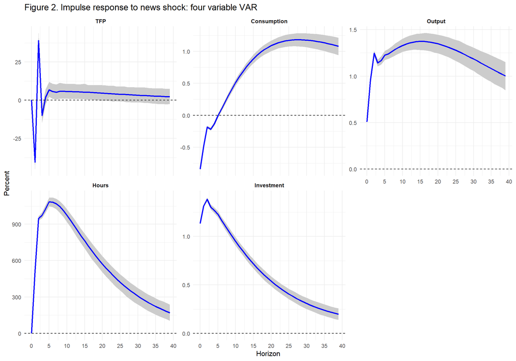

```r
graficar_irf(irf_Y4_news, H, Y4_names, "Figure 2. Impulse response to news shock: four variable VAR")
```

## Figura 3. Surprise technology shock, VAR de 4 variables

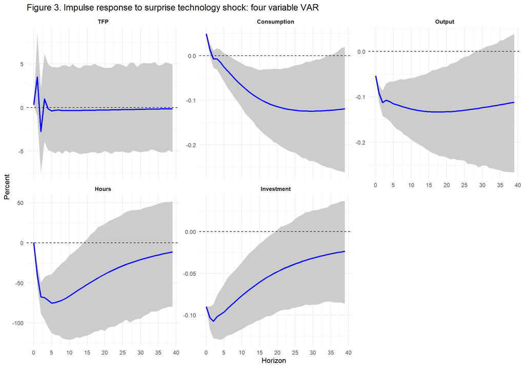

```r
graficar_irf(irf_Y4_surp, H, Y4_names, "Figure 3. Impulse response to surprise technology shock: four variable VAR")
```

## Figuras 4 y 5. News shock, VAR de 7 variables

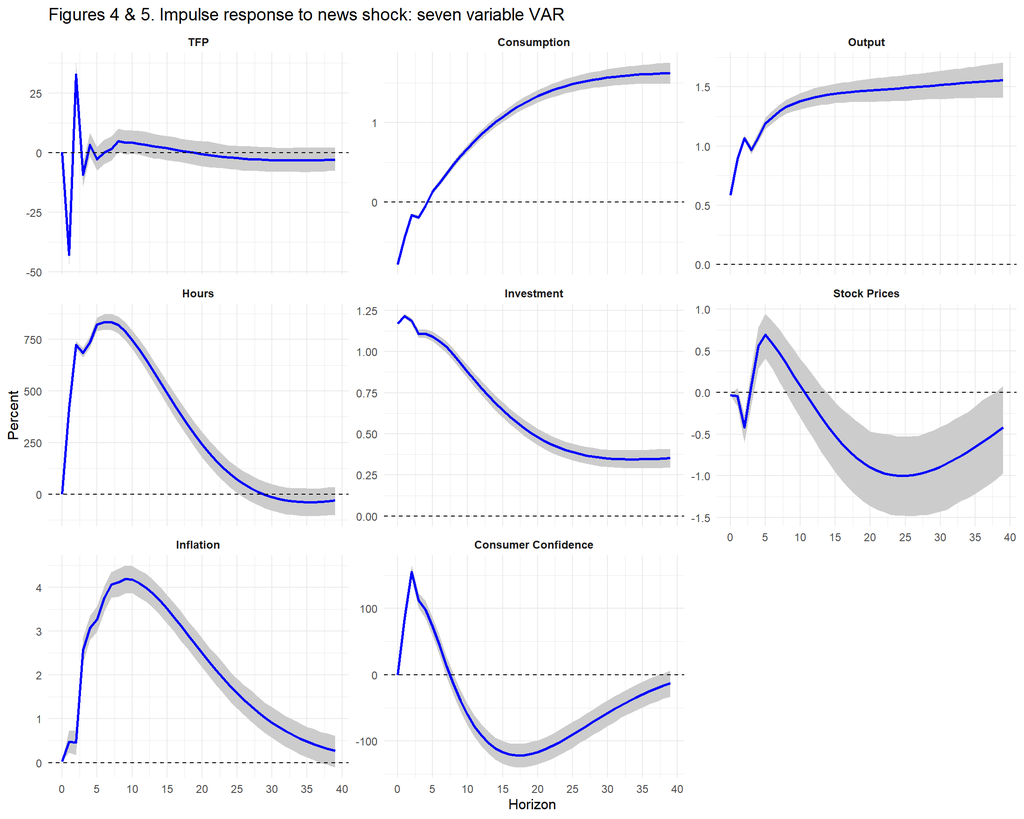

```r
graficar_irf(irf_Y7_news, H, Y7_names, "Figures 4 & 5. Impulse response to news shock: seven variable VAR")
```

## Figura 6. Surprise technology shock, VAR de 7 variables

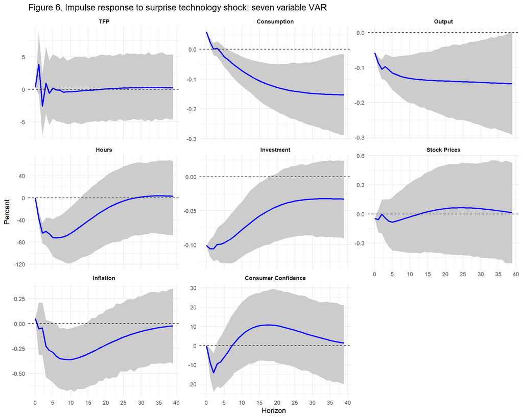

```r
graficar_irf(irf_Y7_surp, H, Y7_names, "Figure 6. Impulse response to surprise technology shock: seven variable VAR")
```

# Contraste con los resultados reportados

## 1. Selección de rezagos (`.mat` y PDF)

```r
tab <- data.frame(
  Modelo   = rep(c("Y4", "Y7"), each = 3),
  Criterio = rep(criterias, 2),
  R        = c(results$Y4$nlags, results$Y7$nlags),
  MATLAB   = c(ref$Y4$nlags, ref$Y7$nlags),
  `PDF (nota 1)` = c(NA, 2, NA, NA, 1, NA), check.names = FALSE)
tab$Coincide <- ifelse(tab$R == tab$MATLAB, "sí", "NO")
kable(tab, caption = "Número óptimo de rezagos")
```

Número óptimo de rezagos

| Modelo | Criterio | R | MATLAB | PDF (nota 1) | Coincide |
| --- | --- | --- | --- | --- | --- |
| Y4 | AIC | 4 | 4 | NA | sí |
| Y4 | SIC | 2 | 2 | 2 | sí |
| Y4 | HQC | 2 | 2 | NA | sí |
| Y7 | AIC | 4 | 4 | NA | sí |
| Y7 | SIC | 1 | 1 | 1 | sí |
| Y7 | HQC | 2 | 2 | NA | sí |

```r
crit_diff <- c(
  Y4 = max(sapply(criterias, function(cr) maxdiff(results$Y4$crit[, cr], ref$Y4[[cr]]))),
  Y7 = max(sapply(criterias, function(cr) maxdiff(results$Y7$crit[, cr], ref$Y7[[cr]]))))
cat("Máx. diferencia absoluta en los criterios de información (R vs MATLAB):\n"); print(crit_diff)
```

```
## Máx. diferencia absoluta en los criterios de información (R vs MATLAB):
```

```
##           Y4           Y7
## 1.529779e-10 4.303269e-10
```

## 2. Coeficientes y matriz de covarianzas del VAR

```r
cmp_var <- function(nm) {
  vr <- ref[[nm]]$VAR; vm <- results[[nm]]$VAR
  coef_ref <- lapply(vr[[11]], function(x) x[[1]])
  c(const = maxdiff(vm$const, vr[[2]]),
    coef  = max(mapply(maxdiff, vm$coef, coef_ref)),
    Omega = maxdiff(vm$Omega, vr[[4]]),
    loglike = abs(vm$loglike - vr[[5]]))
}
kable(rbind(Y4 = cmp_var("Y4"), Y7 = cmp_var("Y7")), digits = 10,
      caption = "Máxima diferencia absoluta R vs MATLAB")
```

Máxima diferencia absoluta R vs MATLAB

|  | const | coef | Omega | loglike |
| --- | --- | --- | --- | --- |
| Y4 | 9.5e-09 | 1.9438e-06 | 0 | 1.7e-09 |
| Y7 | 2.1e-08 | 8.1640e-07 | 0 | 1.0e-09 |

## 3. Shocks identificados

```r
cmp_sh <- data.frame(
  Shock = c("News Y4", "Surprise Y4", "News Y7", "Surprise Y7"),
  `Máx. dif. abs.` = c(
    maxdiff(alinear(results$Y4$news_shock, ref$Y4$news), ref$Y4$news),
    maxdiff(results$Y4$surprise_tech_shock, ref$Y4$surprise),
    maxdiff(alinear(results$Y7$news_shock, ref$Y7$news), ref$Y7$news),
    maxdiff(results$Y7$surprise_tech_shock, ref$Y7$surprise)),
  `Signo coincide sin alinear` = c(
    sum(results$Y4$news_shock * ref$Y4$news) > 0, TRUE,
    sum(results$Y7$news_shock * ref$Y7$news) > 0, TRUE),
  check.names = FALSE)
kable(cmp_sh, digits = 8, caption = "Shocks: R vs MATLAB (news shock alineado en signo)")
```

Shocks: R vs MATLAB (news shock alineado en signo)

| Shock | Máx. dif. abs. | Signo coincide sin alinear |
| --- | --- | --- |
| News Y4 | 0 | TRUE |
| Surprise Y4 | 0 | TRUE |
| News Y7 | 0 | TRUE |
| Surprise Y7 | 0 | TRUE |

## 4. Funciones impulso-respuesta (estimación puntual y bandas)

```r
cmp_irf <- function(mine, refl, nm) {
  # refl = lista (irf, lower, upper) de MATLAB
  ri <- refl[[1]]; rl <- refl[[2]]; ru <- refl[[3]]
  data.frame(
    Figura = nm,
    `Máx. dif. IRF puntual`   = maxdiff(mine$irf, ri),
    `Ancho banda R (prom.)`   = mean(mine$upper - mine$lower),
    `Ancho banda MATLAB (prom.)` = mean(ru - rl),
    `Cociente de anchos`      = mean(mine$upper - mine$lower) / mean(ru - rl),
    check.names = FALSE)
}
kable(rbind(
  cmp_irf(irf_Y4_news, ref$Y4$irf$news4, "Fig. 2 (news, Y4)"),
  cmp_irf(irf_Y4_surp, ref$Y4$irf$sur4,  "Fig. 3 (surprise, Y4)"),
  cmp_irf(irf_Y7_news, ref$Y4$irf$news7, "Fig. 4-5 (news, Y7)"),
  cmp_irf(irf_Y7_surp, ref$Y4$irf$sur7,  "Fig. 6 (surprise, Y7)")),
  digits = 4, caption = "IRF: R vs MATLAB (las bandas dependen del RNG; ver nota)")
```

IRF: R vs MATLAB (las bandas dependen del RNG; ver nota)

| Figura | Máx. dif. IRF puntual | Ancho banda R (prom.) | Ancho banda MATLAB (prom.) | Cociente de anchos |
| --- | --- | --- | --- | --- |
| Fig. 2 (news, Y4) | 0 | 24.5584 | 25.0201 | 0.9815 |
| Fig. 3 (surprise, Y4) | 0 | 24.4087 | 24.9272 | 0.9792 |
| Fig. 4-5 (news, Y7) | 0 | 18.8129 | 19.6379 | 0.9580 |
| Fig. 6 (surprise, Y7) | 0 | 19.3453 | 19.8549 | 0.9743 |

La IRF puntual no depende del azar y debe coincidir; las bandas sí dependen de la semilla/generador, por lo que solo se espera una magnitud similar (cociente de anchos cercano a 1).

## 5. Cifras citadas en el PDF

```r
pdf_claims <- data.frame(
  Afirmación = c("Observaciones", "Período", "Rezagos óptimos SIC (Y4)", "Rezagos óptimos SIC (Y7)",
                 "Ponderador consumo/producto"),
  PDF = c("260", "1960Q1-2024Q4", "2", "1", "0,7432"),
  `Réplica en R` = c(ncol(Y4), paste(base$date[1], "a", base$date[nrow(base)]),
                     results$Y4$nlags["SIC"], results$Y7$nlags["SIC"], round(share_c_calc, 4)),
  check.names = FALSE)
kable(pdf_claims)
```

| Afirmación | PDF | Réplica en R |
| --- | --- | --- |
| Observaciones | 260 | 260 |
| Período | 1960Q1-2024Q4 | 1960:Q1 a 2024:Q4 |
| Rezagos óptimos SIC (Y4) | 2 | 2 |
| Rezagos óptimos SIC (Y7) | 1 | 1 |
| Ponderador consumo/producto | 0,7432 | 0.7432 |

```r
# Comprobaciones cualitativas citadas en el PDF
ancho <- function(x) mean(x$upper - x$lower)
cat("Consumo bajo news shock (Y4), primeros 3 períodos:", round(irf_Y4_news$irf[2, 1:3], 3), "\n")
```

```
## Consumo bajo news shock (Y4), primeros 3 períodos: -0.843 -0.483 -0.184
```

```r
cat("TFP bajo news shock (Y4), primeros 6 períodos:", round(irf_Y4_news$irf[1, 1:6], 2), "\n")
```

```
## TFP bajo news shock (Y4), primeros 6 períodos: 0.15 -40.5 39.03 -9.88 1.93 6.8
```

```r
# Ancho medio de la banda relativo al rango de la IRF puntual, por variable (Y4)
rel <- function(x) round(sapply(1:nrow(x$irf), function(i)
  mean(x$upper[i, ] - x$lower[i, ]) / diff(range(x$irf[i, ]))), 2)
tab_rel <- rbind(news = rel(irf_Y4_news), surprise = rel(irf_Y4_surp))
colnames(tab_rel) <- Y4_names
print(tab_rel)
```

```
##           TFP Consumption Output Hours Investment
## news     0.12        0.08   0.22  0.10       0.08
## surprise 1.56        0.92   2.38  1.49       1.09
```

# Discrepancias y observaciones

## A. Réplica en R vs. `Examen_final.mat` (resultados guardados por MATLAB)

| Elemento | Resultado |
| --- | --- |
| Criterios AIC/SIC/HQC y rezagos óptimos (Y4: 4/2/2; Y7: 4/1/2) | Coinciden (dif. máx. ~1e-10) |
| Coeficientes, constantes, $\Omega$, log-verosimilitud de ambos VAR | Coinciden (dif. máx. ~2e-6, ruido numérico de `solve` vs `/`) |
| *Surprise technology shock* | Coincide exactamente |
| *News shock* (tras ortogonalizar) | Coincide **salvo el signo** del autovector, que es arbitrario; se normalizó a impacto positivo sobre *Hours*, como en el `.mat` |
| IRF puntuales (Figuras 2, 3, 4-5 y 6) | Coinciden exactamente |
| Bandas de confianza (bootstrap) | **Difieren levemente y es inevitable**: el RNG de R no es el de MATLAB (`rng(12345)`). El ancho medio de las bandas es ~2-4 % menor en R; la forma y el orden de magnitud son iguales |

No se encontró ninguna discrepancia numérica atribuible al port en sí.

## B. Discrepancias entre el texto del PDF y el código/resultados

1. **Rezagos usados.** El PDF (punto 4 del resumen) dice que los VAR se estiman con el número óptimo según SIC. El código usa **3 rezagos** (la línea con SIC está comentada). El PDF lo aclara en la nota 1, pero el resumen del punto 4 queda inconsistente con lo ejecutado. Los óptimos según SIC (2 y 1) sí se reproducen.
2. **Figuras/Tabla incompletas.** La consigna pide las Figuras 1 a 7 y, como crédito extra, la Tabla 1. El código solo tiene los encabezados vacíos de las Figuras 1 y 7, y el PDF presenta 2 a 6. No es una diferencia numérica, pero conviene dejarlo explícito.
3. **“Bootstrap con 2.000 réplicas”.** El PDF lo presenta como un bootstrap de la IRF, pero el código (i) no re-estima el VAR en cada réplica, (ii) toma la IRF determinística y le suma un residuo remuestreado en cada horizonte (`randi(T)` dentro del bucle, sobre un conjunto ya remuestreado con `idx`: doble remuestreo). Por eso las bandas no tienen la interpretación habitual de incertidumbre de estimación. Esto explica la observación del PDF de que las bandas del *news shock* son mucho más angostas y las del *surprise shock* mucho más anchas que en el paper: en esta réplica el ancho medio de banda relativo al rango de la IRF es ~0,1 para el *news shock* y ~1 a 2 para el *surprise shock* (tabla de la sección anterior).
4. **Afirmaciones cualitativas del PDF: se reproducen todas.**
   - La IRF de TFP es errática en los primeros períodos (valores de ±40 que luego caen a ~0).
   - La IRF de *consumption* ante el *news shock* es negativa al inicio (-0,84, -0,48, -0,18), cuando en el paper nunca lo es.
   - 260 observaciones, 1960Q1-2024Q4 y ponderador 0,7432 (se recalcula desde `Base.xlsx`): coinciden.

## C. Posibles causas de la discrepancia con el paper (observaciones sobre el código; no se corrigieron)

El PDF sugiere que las diferencias con el paper pueden deberse a la identificación. Revisando el código, hay puntos concretos que lo explicarían:

1. **`A0_inv` es en realidad `inv(chol(Omega))`.** Para el impacto contemporáneo de los shocks estructurales se necesita el factor de Cholesky $P$ ($\Omega = PP'$), no su inversa. El *surprise technology shock* se toma como `A0_inv(:,1)`, que no es la primera columna de $P$.
2. **El vector `gamma` del *news shock* vive en el espacio de shocks ortogonalizados**, pero se usa directamente como vector de impacto sobre las variables (`irf(1:k,1) = shock`) sin multiplicar por la matriz de impacto.
3. **Se rompe la restricción de impacto nulo sobre TFP.** El *news shock* identificado tiene TFP = 0 en la primera componente, pero al ortogonalizarlo contra el *surprise shock* (`news - proj`) esa componente deja de ser cero. En esta réplica la respuesta de TFP en $t=0$ es 0.154 (VAR de 4 variables) y 0.167 (VAR de 7 variables), en lugar de 0 como en la Figura 2 del paper.
4. **`calcular_R` omite el horizonte 0** (usa $\Psi_1,\dots,\Psi_H$) y maximiza la suma de cuadrados de la respuesta de TFP, no la participación en la varianza del error de pronóstico a horizonte 40 que usan Barsky y Sims.
5. **Unidades.** *Hours* se usa en niveles (~840), no en logaritmos. Por eso su IRF alcanza ~1000 y la etiqueta “Percent” del eje no es correcta para esa variable.
6. **Convención de nombres.** Las IRF del VAR de 7 variables se guardan en `results.Y4.irf_Y7_*` (no en `results.Y7`), algo a tener en cuenta al leer el `.mat`.